# American Religious Identification Survey (ARIS) Datasets, 2008 and 2001

## Contingency Tables

```r
prop.table(table(ARIS2008_major$RELIG, ARIS2008_major$POLAFFIL), margin=1)
```

```
                                                      A Democrat A Republican An Independent
  Baptist                                            0.409696970  0.284155844    0.230129870
  Catholic, Roman Catholic                           0.349144171  0.262624542    0.302733543
  Christian                                          0.254428537  0.369570493    0.302353798
  Don't know                                         0.300601202  0.140280561    0.364729459
  Episcopalian/Anglican                              0.336092715  0.324503311    0.286423841
  Jewish, Judaism                                    0.527412281  0.143640351    0.279605263
  Lutheran                                           0.300906056  0.346208870    0.271816881
  Methodist/Wesleyan                                 0.345850999  0.336765597    0.252574197
  Mormon/Church of Jesus Christ of Latter-day Saints 0.117496807  0.549169860    0.263090677
  No religion/none                                   0.345891966  0.142532910    0.410198215
  Non-denominational Christian                       0.273087071  0.306068602    0.329815303
  Pentecostal                                        0.373056995  0.278497409    0.237046632
  Presbyterian                                       0.287575150  0.405811623    0.256513026
  Protestant                                         0.266201009  0.383391541    0.289483896
  Refused                                            0.214257109  0.136964357    0.299959952
  Southern Baptist                                   0.295711061  0.415349887    0.250564334
  United Methodist                                   0.333333333  0.344000000    0.264000000

                                                      Don't know       Other     Refused
  Baptist                                            0.036190476 0.009696970 0.030129870
  Catholic, Roman Catholic                           0.034403474 0.013625138 0.037469131
  Christian                                          0.029119146 0.016622179 0.027905848
  Don't know                                         0.112224449 0.016032064 0.066132265
  Episcopalian/Anglican                              0.013245033 0.014900662 0.024834437
  Jewish, Judaism                                    0.010964912 0.014254386 0.024122807
  Lutheran                                           0.033381021 0.012398665 0.035288507
  Methodist/Wesleyan                                 0.031496063 0.004239855 0.029073289
  Mormon/Church of Jesus Christ of Latter-day Saints 0.029374202 0.014048531 0.026819923
  No religion/none                                   0.044484793 0.018610985 0.038281132
  Non-denominational Christian                       0.032981530 0.022427441 0.035620053
  Pentecostal                                        0.050518135 0.014248705 0.046632124
  Presbyterian                                       0.016032064 0.013026052 0.021042084
  Protestant                                         0.022700815 0.009507179 0.028715561
  Refused                                            0.022426912 0.019223068 0.307168602
  Southern Baptist                                   0.015801354 0.011286682 0.011286682
  United Methodist                                   0.024000000 0.008000000 0.026666667
```

```r
prop.table(table(ARIS2008_major$RELIG, ARIS2008_major$REGVOTE), margin=1)
```

```
                                                      Don't know          No     Refused         Yes
  Baptist                                            0.004675325 0.128658009 0.007099567 0.859567100
  Catholic, Roman Catholic                           0.003235970 0.133866985 0.014221238 0.848675807
  Christian                                          0.005095851 0.140499879 0.007037127 0.847367144
  Don't know                                         0.018036072 0.214428858 0.018036072 0.749498998
  Episcopalian/Anglican                              0.003311258 0.086092715 0.003311258 0.907284768
  Jewish, Judaism                                    0.008771930 0.081140351 0.006578947 0.903508772
  Lutheran                                           0.004768717 0.090605627 0.007153076 0.897472580
  Methodist/Wesleyan                                 0.003634161 0.083585706 0.008479709 0.904300424
  Mormon/Church of Jesus Christ of Latter-day Saints 0.002554278 0.108556833 0.003831418 0.885057471
  No religion/none                                   0.005144500 0.188076865 0.008473294 0.798305341
  Non-denominational Christian                       0.003957784 0.160949868 0.003957784 0.831134565
  Pentecostal                                        0.010362694 0.176165803 0.007772021 0.805699482
  Presbyterian                                       0.000000000 0.067134269 0.007014028 0.925851703
  Protestant                                         0.002716337 0.077609624 0.005820722 0.913853318
  Refused                                            0.004405286 0.082098518 0.148177813 0.765318382
  Southern Baptist                                   0.004514673 0.110609481 0.004514673 0.880361174
  United Methodist                                   0.002666667 0.078666667 0.002666667 0.916000000
```

## State FIPS Codes

```r
sort(unique(ARIS2008$STATE))
```

```
 [1] "AL" "AR" "AZ" "CA" "CO" "CT" "DC" "DE" "FL" "GA" "IA" "ID" "IL" "IN" "KS" "KY" "LA" "MA" "MD"
[20] "ME" "MI" "MN" "MO" "MS" "MT" "NC" "ND" "NE" "NH" "NJ" "NM" "NV" "NY" "OH" "OK" "OR" "PA" "RI"
[39] "SC" "SD" "TN" "TX" "UT" "VA" "VT" "WA" "WI" "WV" "WY"
```

[State FIPS Codes](https://www.nrcs.usda.gov/wps/portal/nrcs/detail/?cid=nrcs143_013696)

```r
lower_48 <- c("01", "04", "05", "06", "08", "09", "10", "11", "12", "13", "16", "17", "18", "19", "20", "21", "22", "23", "24", "25", "26", "27", "28", "29", "30", "31", "32", "33", "34", "35", "36", "37", "38", "39", "40", "41", "42", "44", "45", "46", "47", "48", "49", "50", "51", "53", "54", "55", "56")
```

## States Shapefile

United States Census Bureau, [Cartographic Boundary Files - Shapefile](https://www.census.gov/geographies/mapping-files/time-series/geo/carto-boundary-file.html)

cb_2018_us_state_500k.zip

```r
states.sh <- readOGR("C:/Users/14165/Desktop/Shapefiles/cb_2018_us_state_500k", "cb_2018_us_state_500k", stringsAsFactors=FALSE)
```

```r
str(states.sh@data)
```

```
'data.frame':   56 obs. of  9 variables:
 $ STATEFP : chr  "28" "37" "40" "51" ...
 $ STATENS : chr  "01779790" "01027616" "01102857" "01779803" ...
 $ AFFGEOID: chr  "0400000US28" "0400000US37" "0400000US40" "0400000US51" ...
 $ GEOID   : chr  "28" "37" "40" "51" ...
 $ STUSPS  : chr  "MS" "NC" "OK" "VA" ...
 $ NAME    : chr  "Mississippi" "North Carolina" "Oklahoma" "Virginia" ...
 $ LSAD    : chr  "00" "00" "00" "00" ...
 $ ALAND   : chr  "121533519481" "125923656064" "177662925723" "102257717110" ...
 $ AWATER  : chr  "3926919758" "13466071395" "3374587997" "8528531774" ...
```

```r
states_lower48.sh <- states.sh[states.sh@data$GEOID %in% lower_48,]
```

```r
str(states_lower48.sh@data)
```

```
'data.frame':   49 obs. of  9 variables:
 $ STATEFP : chr  "28" "37" "40" "51" ...
 $ STATENS : chr  "01779790" "01027616" "01102857" "01779803" ...
 $ AFFGEOID: chr  "0400000US28" "0400000US37" "0400000US40" "0400000US51" ...
 $ GEOID   : chr  "28" "37" "40" "51" ...
 $ STUSPS  : chr  "MS" "NC" "OK" "VA" ...
 $ NAME    : chr  "Mississippi" "North Carolina" "Oklahoma" "Virginia" ...
 $ LSAD    : chr  "00" "00" "00" "00" ...
 $ ALAND   : chr  "121533519481" "125923656064" "177662925723" "102257717110" ...
 $ AWATER  : chr  "3926919758" "13466071395" "3374587997" "8528531774" ...
```

Add “id” column

```r
states_lower48.sh@data$id <- as.integer(states_lower48.sh@data$GEOID)
```

```r
sort(states_lower48.sh@data$id)
```

```
 [1]  1  4  5  6  8  9 10 11 12 13 16 17 18 19 20 21 22 23 24 25 26 27 28 29 30 31 32 33 34 35 36 37
[33] 38 39 40 41 42 44 45 46 47 48 49 50 51 53 54 55 56
```

```r
states_lower48.sh@data$STATE <- as.character(states_lower48.sh@data$STUSPS)
```

Shapefile processing

```r
states_lower48.points = fortify(states_lower48.sh, region = "id")

states_lower48.df = join(states_lower48.points, states_lower48.sh@data, by = "id")
```

## State Religious Ratios and Choropleths

```r
Totals2008 <- ARIS2008[, .(.N), by = .(STATE)]

Totals2008 <- Totals2008[order(STATE)]
```

### Catholics

```r
Catholics2008 <- ARIS2008[RELIG == "Catholic, Roman Catholic", .(.N), by = .(STATE)]

Catholics2008 <- Catholics2008[order(STATE)]

Catholics2008$ratio <- Catholics2008$N/Totals2008$N

Catholics2008_lower48 <- merge(states_lower48.df, Catholics2008, by = "STATE")

Catholics2008_lower48 <- Catholics2008_lower48[order(Catholics2008_lower48$STATE), ]
```

Make and plot choropleth

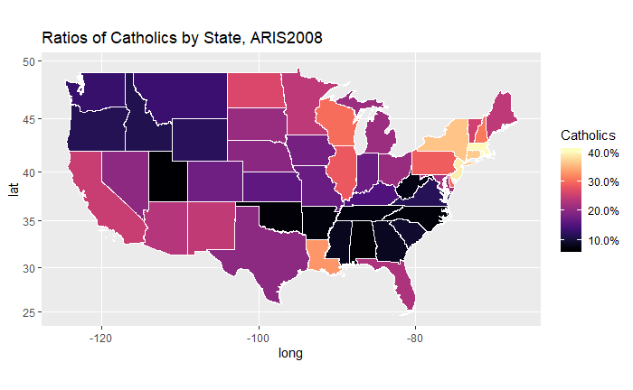

```r
ggplot() +
  geom_polygon(data = Catholics2008_lower48,
               aes(x = long, y = lat, group = group, fill = ratio),
               color = "white", size = 0.1) +
  coord_map() +
  scale_fill_viridis(option="magma", labels=percent, name="Catholics") +
   labs(title="Ratios of Catholics by State, ARIS2008")
```

### Baptists

```r
Baptists2008 <- ARIS2008[RELIG == "Baptist", .(.N), by = .(STATE)]

Baptists2008 <- Baptists2008[order(STATE)]

Baptists2008$ratio <- Baptists2008$N/Totals2008$N

Baptists2008_lower48 <- merge(states_lower48.df, Baptists2008, by = "STATE")

Baptists2008_lower48 <- Baptists2008_lower48[order(Baptists2008_lower48$STATE), ]
```

Make and plot choropleth

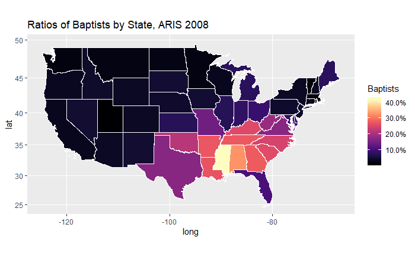

```r
ggplot() +
  geom_polygon(data = Baptists2008_lower48,
               aes(x = long, y = lat, group = group, fill = ratio),
               color = "white", size = 0.1) +
  coord_map() +
  scale_fill_viridis(option="magma", labels=percent, name="Baptists") +
   labs(title="Ratios of Baptists by State, ARIS 2008")
```

### No Religion

```r
Noreligion2008 <- ARIS2008[RELIG == "No religion/none", .(.N), by = .(STATE)]

Noreligion2008 <- Noreligion2008[order(STATE)]

Noreligion2008$ratio <- Noreligion2008$N/Totals2008$N

Noreligion2008_lower48 <- merge(states_lower48.df, Noreligion2008, by = "STATE")

Noreligion2008_lower48 <- Noreligion2008_lower48[order(Noreligion2008_lower48$STATE), ]
```

Make and plot choropleth

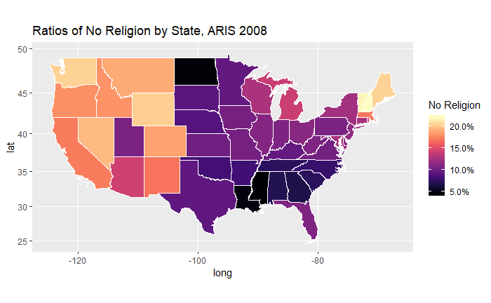

```r
ggplot() +
  geom_polygon(data = Noreligion2008_lower48,
               aes(x = long, y = lat, group = group, fill = ratio),
               color = "white", size = 0.1) +
  coord_map() +
  scale_fill_viridis(option="magma", labels=percent, name="No Religion") +
   labs(title="Ratios of No Religion by State, ARIS 2008")
```

# ARIS 2001

[Download ARIS 2001 Data](https://commons.trincoll.edu/aris/surveys/aris-2001/download-aris-2001/)

ARIS2001SPSS.zip

```r
ARIS2001 <- fread("ARIS2001.csv")
```

[ARIS 2001 Codebook](https://commons.trincoll.edu/aris/surveys/aris-2001/aris-2001-codebook/)

```r
ARIS2001 <- ARIS2001[, .(POPWGHT = wgt_pop, STATE = state, COUNTYFIPS = fips, ADI = adi, DMA = dma, MSA = msa, METRO = metro, NIELSEN = neilsen, DIVISION = cen_div, REGION = region, SEX = gender, OWNHOME = dem2, MARITAL = dem3, EMPLOY = dem4, INCOME = newdem9, AGE = dem7, EDUC = dem8, HISPANIC = dem10, RACE = dem11, RELIG = jq1tot, RELIG_SPOUSE = jq2tot, AGECAT = agecat, POLAFFIL = z11a, REGVOTE = z11b)]
```

```r
ARIS2001$STATE <- state2abbr(ARIS2001$STATE)
```

```r
major_2001 <- names(head(sort(prop.table(table(ARIS2001$RELIG)), decreasing=TRUE), 17))

major_2001
```

```
 [1] "Catholic"                                "Baptist"
 [3] "None"                                    "Methodist/Wesleyan"
 [5] "Christian"                               "Refused"
 [7] "Lutheran"                                "Presbyterian"
 [9] "Protestant"                              "Pentecostal/Charismatics"
[11] "Southern Baptist"                        "Episcopalian"
[13] "Mormon/Latter Day Saints"                "Churches of Christ & Christian Churches"
[15] "Non-denominational"                      "Jewish/Judaism"
[17] "United Church of Christ/Congregational"
```

```r
ARIS2001_major <- ARIS2001[RELIG %in% major_2001,]

nrow(ARIS2001_major)
```

```
[1] 46021
```

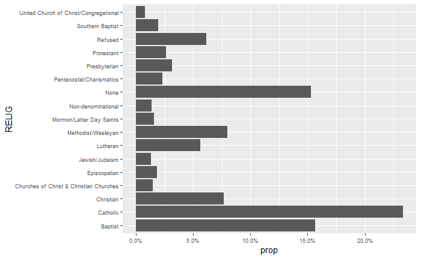

```r
ggplot(ARIS2001_major, aes(RELIG)) +
  geom_bar(mapping = aes(x = RELIG, y = ..prop.., group = 1), stat = "count") +
  scale_y_continuous(labels = scales::percent) +
  coord_flip()+theme(axis.text = element_text(size = 7))
```

```r
Totals2001 <- ARIS2001[, .(.N), by = .(STATE)]

Totals2001 <- Totals2001[order(STATE)]
```

## Catholics

```r
Catholics2001 <- ARIS2001[RELIG == "Catholic", .(.N), by = .(STATE)]

Catholics2001 <- Catholics2001[order(STATE)]

Catholics2001$ratio <- Catholics2001$N/Totals2001$N

Catholics2001_lower48 <- merge(states_lower48.df, Catholics2001, by = "STATE")

Catholics2001_lower48 <- Catholics2001_lower48[order(Catholics2001_lower48$STATE), ]
```

Make and plot choropleth

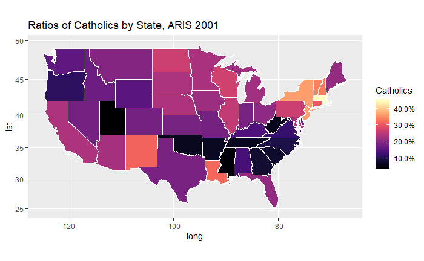

```r
ggplot() +
  geom_polygon(data = Catholics2001_lower48,
               aes(x = long, y = lat, group = group, fill = ratio),
               color = "white", size = 0.1) +
  coord_map() +
  scale_fill_viridis(option="magma", labels=percent, name="Catholics") +
   labs(title="Ratios of Catholics by State, ARIS 2001")
```

## Baptists

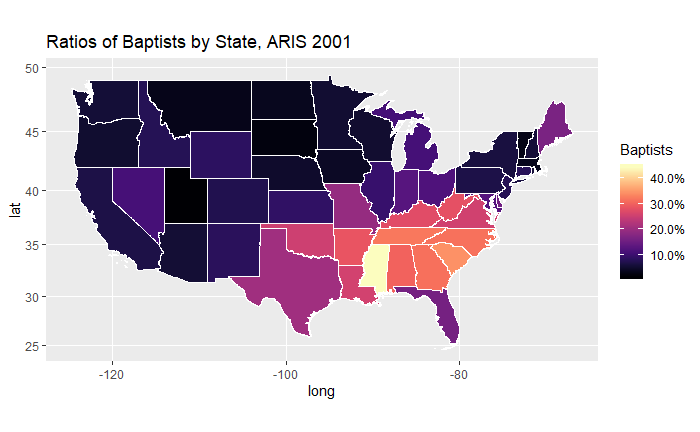

```r
Baptists2001 <- ARIS2001[RELIG == "Baptist", .(.N), by = .(STATE)]

Baptists2001 <- Baptists2001[order(STATE)]

Baptists2001$ratio <- Baptists2001$N/Totals2001$N

Baptists2001_lower48 <- merge(states_lower48.df, Baptists2001, by = "STATE")

Baptists2001_lower48 <- Baptists2001_lower48[order(Baptists2001_lower48$STATE), ]

ggplot() +
  geom_polygon(data = Baptists2001_lower48,
               aes(x = long, y = lat, group = group, fill = ratio),
               color = "white", size = 0.1) +
  coord_map() +
  scale_fill_viridis(option="magma", labels=percent, name="Baptists") +
   labs(title="Ratios of Baptists by State, ARIS 2001")
```

## No Religion

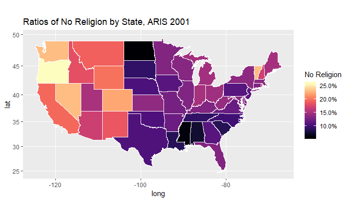

```r
Noreligion2001 <- ARIS2001[RELIG == "None", .(.N), by = .(STATE)]

Noreligion2001 <- Noreligion2001[order(STATE)]

Noreligion2001$ratio <- Noreligion2001$N/Totals2001$N

Noreligion2001_lower48 <- merge(states_lower48.df, Noreligion2001, by = "STATE")

Noreligion2001_lower48 <- Noreligion2001_lower48[order(Noreligion2001_lower48$STATE), ]

ggplot() +
  geom_polygon(data = Noreligion2001_lower48,
               aes(x = long, y = lat, group = group, fill = ratio),
               color = "white", size = 0.1) +
  coord_map() +
  scale_fill_viridis(option="magma", labels=percent, name="No Religion") +
   labs(title="Ratios of No Religion by State, ARIS 2001")
```

# Change from 2001 to 2008

## Catholics

```r
Catholics2008$change <- (Catholics2008$ratio-Catholics2001$ratio)/Catholics2001$ratio
```

```r
Catholics2008change_lower48 <- merge(states_lower48.df, Catholics2008, by = "STATE")

Catholics2008change_lower48 <- Catholics2008change_lower48[order(Catholics2008change_lower48$STATE), ]
```

Make and plot choropleth

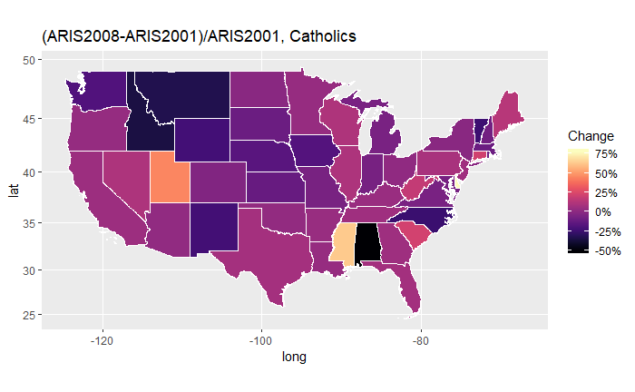

```r
ggplot() +
  geom_polygon(data = Catholics2008change_lower48,
               aes(x = long, y = lat, group = group, fill = change),
               color = "white", size = 0.1) +
  coord_map() +
  scale_fill_viridis(option="magma", labels=percent, name="Change") +
   labs(title="(ARIS2008-ARIS2001)/ARIS2001, Catholics")
```

## Baptists

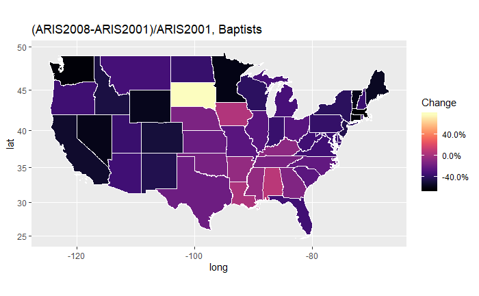

```r
Baptists2008$change <- (Baptists2008$ratio-Baptists2001$ratio)/Baptists2001$ratio

Baptists2008change_lower48 <- merge(states_lower48.df, Baptists2008, by = "STATE")

Baptists2008change_lower48 <- Baptists2008change_lower48[order(Baptists2008change_lower48$STATE), ]

ggplot() +
  geom_polygon(data = Baptists2008change_lower48,
               aes(x = long, y = lat, group = group, fill = change),
               color = "white", size = 0.1) +
  coord_map() +
  scale_fill_viridis(option="magma", labels=percent, name="Change") +
   labs(title="(ARIS2008-ARIS2001)/ARIS2001, Baptists")
```

## No Religion

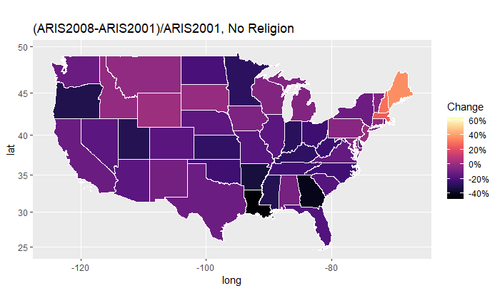

```r
Noreligion2008$change <- (Noreligion2008$ratio-Noreligion2001$ratio)/Noreligion2001$ratio

Noreligion2008change_lower48 <- merge(states_lower48.df, Noreligion2008, by = "STATE")

Noreligion2008change_lower48 <- Noreligion2008change_lower48[order(Noreligion2008change_lower48$STATE), ]

ggplot() +
  geom_polygon(data = Noreligion2008change_lower48,
               aes(x = long, y = lat, group = group, fill = change),
               color = "white", size = 0.1) +
  coord_map() +
  scale_fill_viridis(option="magma", labels=percent, name="Change") +
   labs(title="(ARIS2008-ARIS2001)/ARIS2001, No Religion")
```

# ARIS 2008 Density Maps

## State and County FIPS Codes

[State FIPS Codes](https://www.nrcs.usda.gov/wps/portal/nrcs/detail/?cid=nrcs143_013696)

[County FIPS Codes](https://www.nrcs.usda.gov/wps/portal/nrcs/detail/national/home/?cid=nrcs143_013697)

```r
ARIS2008_counties <- ARIS2008[,.(COUNTYFIPS = COUNTYC, STATE, RELIG)]

ARIS2008_counties$STATEFIPS <- fips(ARIS2008_counties$STATE, to = "FIPS")
```

## Counties Shapefile

United States Census Bureau, [Cartographic Boundary Files - Shapefile](https://www.census.gov/geographies/mapping-files/time-series/geo/carto-boundary-file.html)

cb_2018_us_county_500k.zip

```r
counties.sh <- readOGR("C:/Users/14165/Desktop/Shapefiles/cb_2018_us_county_500k", "cb_2018_us_county_500k", stringsAsFactors=FALSE)
```

```r
str(counties.sh@data)
```

```
'data.frame':   3233 obs. of  9 variables:
 $ STATEFP : chr  "21" "21" "21" "21" ...
 $ COUNTYFP: chr  "007" "017" "031" "065" ...
 $ COUNTYNS: chr  "00516850" "00516855" "00516862" "00516879" ...
 $ AFFGEOID: chr  "0500000US21007" "0500000US21017" "0500000US21031" "0500000US21065" ...
 $ GEOID   : chr  "21007" "21017" "21031" "21065" ...
 $ NAME    : chr  "Ballard" "Bourbon" "Butler" "Estill" ...
 $ LSAD    : chr  "06" "06" "06" "06" ...
 $ ALAND   : chr  "639387454" "750439351" "1103571974" "655509930" ...
 $ AWATER  : chr  "69473325" "4829777" "13943044" "6516335" ...
```

```r
counties_lower48.sh <- counties.sh[counties.sh@data$STATEFP %in% lower_48,]
```

```r
counties_lower48.sh@data$STATEFIPS <- as.integer(counties_lower48.sh@data$STATEFP)

counties_lower48.sh@data$COUNTYFIPS <- as.integer(counties_lower48.sh@data$COUNTYFP)
```

```r
counties_lower48.centroids  <- as.data.table(gCentroid(counties_lower48.sh, byid = TRUE))

counties_lower48.centroids$STATEFIPS <- counties_lower48.sh@data$STATEFIPS

counties_lower48.centroids$COUNTYFIPS <- counties_lower48.sh@data$COUNTYFIPS
```

```r
str(counties_lower48.centroids)
```

```
Classes ‘data.table’ and 'data.frame':  3108 obs. of  4 variables:
 $ x         : num  -89 -84.2 -86.7 -84 -83.7 ...
 $ y         : num  37.1 38.2 37.2 37.7 38.4 ...
 $ STATEFIPS : int  21 21 21 21 21 21 21 21 21 21 ...
 $ COUNTYFIPS: int  7 17 31 65 69 93 99 131 151 155 ...
 - attr(*, ".internal.selfref")=<externalptr>
```

```r
str(ARIS2008_counties)
```

```
Classes ‘data.table’ and 'data.frame':  54461 obs. of  4 variables:
 $ COUNTYFIPS: int  137 401 15 81 59 25 19 5 77 85 ...
 $ STATE     : chr  "GA" "TX" "AZ" "CA" ...
 $ RELIG     : chr  "Don't know" "Catholic, Roman Catholic" "Apostolic/New Apostolic" "Catholic, Roman Catholic" ...
 $ STATEFIPS : int  13 48 4 6 13 34 23 25 53 6 ...
 - attr(*, ".internal.selfref")=<externalptr>
```

```r
ARIS2008_XY <- left_join(ARIS2008_counties, counties_lower48.centroids, by = c("STATEFIPS", "COUNTYFIPS"))
```

```r
ARIS2008_XY$COUNTYFIPS <- NULL

ARIS2008_XY$STATE <- NULL

ARIS2008_XY$STATEFIPS <- NULL

str(ARIS2008_XY)
```

```
'data.frame':   54461 obs. of  3 variables:
 $ RELIG: chr  "Don't know" "Catholic, Roman Catholic" "Apostolic/New Apostolic" "Catholic, Roman Catholic" ...
 $ x    : num  -83.5 -94.8 -113.8 -122.3 -83.4 ...
 $ y    : num  34.6 32.1 35.7 37.4 34 ...
```

```r
Catholics2008_XY <- ARIS2008_XY[ARIS2008_XY$RELIG == "Catholic, Roman Catholic",]

Catholics2008_XY$RELIG <- NULL
```

```r
Baptists2008_XY <- ARIS2008_XY[ARIS2008_XY$RELIG == "Baptist",]

Baptists2008_XY$RELIG <- NULL
```

```r
Noreligion2008_XY <- ARIS2008_XY[ARIS2008_XY$RELIG == "No religion/none",]

Noreligion2008_XY$RELIG <- NULL
```

## Catholic Density Map

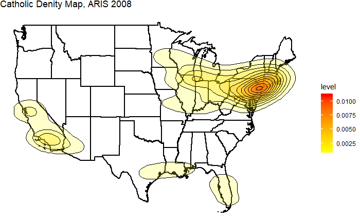

```r
ggplot() +
  geom_polygon(data = states_lower48.df, aes(x = long, y = lat, group = group),
          color = 'black', size = 1, fill=NA) +
  stat_density2d(data=Catholics2008_XY, aes(x=x, y=y, fill=..level..), alpha=0.2, geom = 'polygon', colour = 'black', contour=TRUE) +
  scale_fill_continuous(low="yellow", high="red")+
  theme_nothing(legend = TRUE) +
  labs(title="Catholic Denity Map, ARIS 2008")
```

## Baptist Density Map

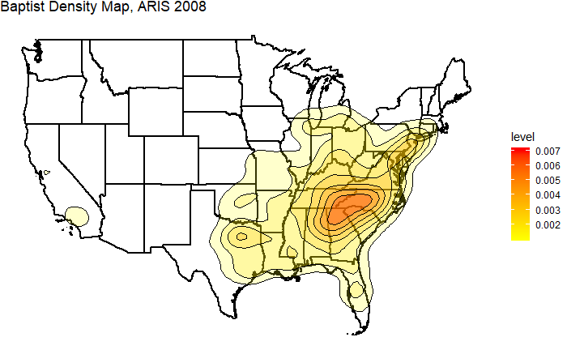

```r
ggplot() +
  geom_polygon(data = states_lower48.df, aes(x = long, y = lat, group = group),
          color = 'black', size = 1, fill=NA) +
  stat_density2d(data=Baptists2008_XY, aes(x=x, y=y, fill=..level..), alpha=0.2, geom = 'polygon', colour = 'black', contour=TRUE) +
  scale_fill_continuous(low="yellow",high="red")+
  theme_nothing(legend = TRUE) +
  labs(title="Baptist Density Map, ARIS 2008")
```

## No Religion Density Map

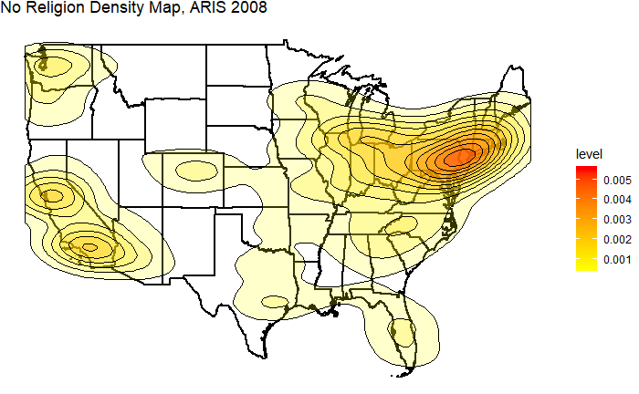

```r
ggplot() +
  geom_polygon(data = states_lower48.df, aes(x = long, y = lat, group = group),
          color = 'black', size = 1, fill=NA) +
  stat_density2d(data=Noreligion2008_XY, aes(x=x, y=y, fill=..level..), alpha=0.2, geom = 'polygon', colour = 'black', contour=TRUE) +
  scale_fill_continuous(low="yellow",high="red")+
  theme_nothing(legend = TRUE) +
  labs(title="No Religion Density Map, ARIS 2008")
```